# Fine-scale heterogeneity in Schistosoma mansoni force of infection measured through antibody response

Figure 2, Figure 3, Figure S4 Comparison of serology and stool based measures at the community level

Ben Arnold ben.arnold@ucsf.edu

run 2020-06-25 16:16:19

# Preamble

```r
library(here)
here()
```

```
## [1] "/Users/benarnold/mbita-schisto"
```

```r
#--------------------------------
# source the configuration file
#--------------------------------
source(here("R/mbita-schisto-Config.R"))
```

# Load and process data

```r
#---------------------------
# mbita PSAC data
#---------------------------
d <- readRDS(here("data","mbita_schisto.rds") )

# create age strata
# create log values for SEA MFI and KK epg
# convert the dist_victoria variable from class units to numeric
d2 <- d %>%
  mutate(agecat = cut(agey,breaks=c(0,1,2,3,4,6),
                      labels=c("<1 year","1 year","2 years","3 years","4 years")),
         logsea = ifelse(sea<=0,log10(1),log10(sea)),
         logepg = ifelse(sm_epg<=0,log10(1),log10(sm_epg))
         )

# create factor variables for modeling (used below)
d3 <- d2 %>%
  ungroup() %>%
  mutate(vid=factor(vid),
         yearf = factor(year),
         dummy=1)

#---------------------------
# collapse to counts at the
# village level, by year
# calculate prevalence
# by SEA and Kato-Katz
#
# also summarize by village
# over all years
#---------------------------

# summarized by village and year
dvil <- d3 %>%
  group_by(vid,year) %>%
  summarize(sea_n = sum(sea_pos,na.rm=T),
            sea_N = sum(ifelse(!is.na(sea_pos),1,0)),
            kk_n = sum(kk_pos,na.rm=T),
            kk_N = sum(ifelse(!is.na(kk_pos),1,0))
            ) %>%
  mutate(sea_prev = sea_n/sea_N,
         kk_prev = kk_n/kk_N,
         yearf = as.factor(year))

# summarized by village (over all years)
dvil2 <- d3 %>%
  group_by(vid) %>%
  summarize(sea_n = sum(sea_pos,na.rm=T),
            sea_N = sum(ifelse(!is.na(sea_pos),1,0)),
            kk_n = sum(kk_pos,na.rm=T),
            kk_N = sum(ifelse(!is.na(kk_pos),1,0))
            ) %>%
  mutate(sea_prev = sea_n/sea_N,
         kk_prev = kk_n/kk_N)
```

# Figure 2

## Figure 2a

Correlation between SEA and KK

Estimate the correlation between village-level SEA seroprevalence and Kato-Katz prevalence using a Spearman rank correlation statistic. Estimate locally weighted smoothers of the relationship between SEA and Kato-Katz in each year and over all years. Trim the smooths to 95% of the data to avoid edge effects.

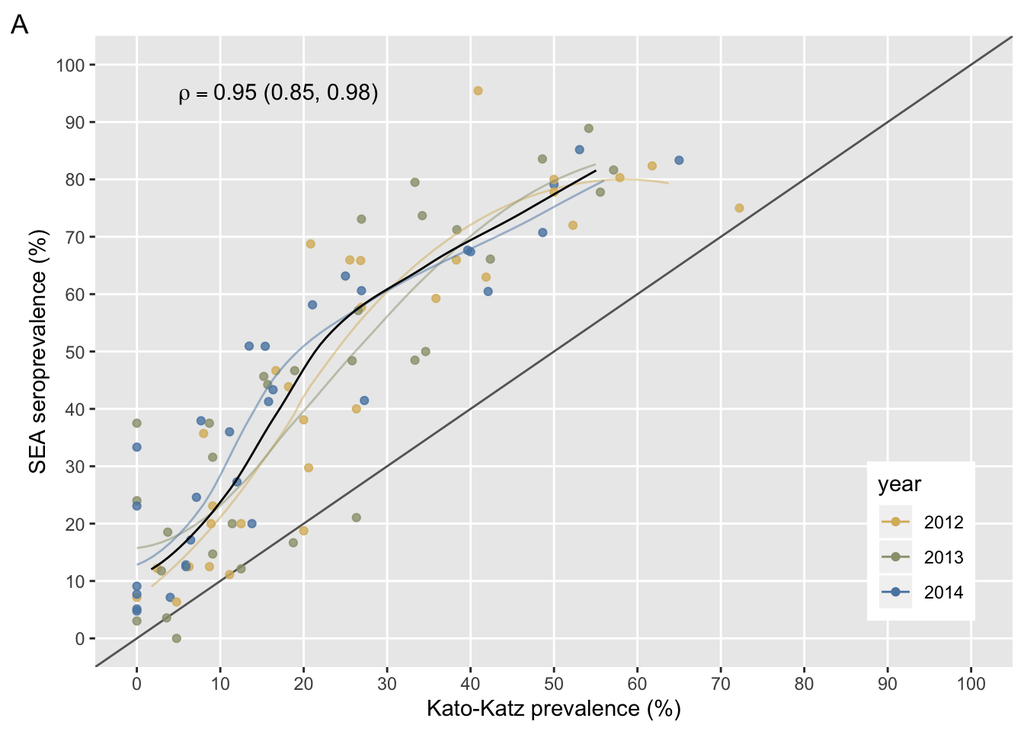

```r
# estimate correlation overall
# bootstrap resample to estimate 95% confidence intervals
cor_sea_kk <- cor(dvil2$sea_prev,dvil2$kk_prev,method="spearman")
set.seed(1721)
cor_sea_kk_boot <- foreach(booti = 1:1000, .combine = rbind) %do% {
  pd <- sample_frac(dvil2,size=1, replace = TRUE)
  cori <- cor(pd$sea_prev,pd$kk_prev,method="spearman")
  cori
}
cor_sea_kk_ci <- quantile(cor_sea_kk_boot,prob = c(0.025,0.975))
cor_sea_kk_print <- paste0(sprintf("%1.2f",cor_sea_kk)," (", sprintf("%1.2f",cor_sea_kk_ci[1]),", ",sprintf("%1.2f",cor_sea_kk_ci[2]),")")

#--------------------------------
# estimate smooths in each year
# trimmed to drop the bottom
# and top 2.5% of data in each
# comparison to avoid edge effects
#--------------------------------
dsmooths <- foreach(yeari=levels(dvil$yearf),.combine=rbind) %do% {
                        pd <- filter(dvil,yearf==yeari)
                        xqs <- quantile(pd$kk_prev,probs=c(0.025,0.975),na.rm=TRUE)
                        yqs <- quantile(pd$sea_prev,probs=c(0.025,0.975),na.rm=TRUE)
                        newd <- data.frame(kk_prev=seq(xqs[1],xqs[2],by=0.01))
                        lfit <- loess(sea_prev~kk_prev,data=pd)
                        return(data.frame(yearf=yeari,
                                          kk_prev=newd$kk_prev,
                                          sea_prev=predict(lfit,newdata=newd))
                        )
}


# pcols <- c(cbPalette[c(3,4,8)])
# use a nice color palette from Trevor Bedford
pcols <- c("#D9B86A", "#9B9F7C", "#5986B0")
# make figure
scatter_sea_kk <- ggplot(data=dvil,aes(x=kk_prev,y=sea_prev, color = yearf))+
  geom_abline(intercept=0,slope=1,color="gray40")+
  geom_point(alpha=0.8) +
  geom_line(data=dsmooths,size=0.5,alpha=0.5)+
  geom_smooth(data=dvil2,method="loess",se=FALSE,color="black",size=0.5)+
  annotate("text",x=0.05,y=0.95,label=paste("rho ==",deparse(cor_sea_kk_print)),parse=TRUE, hjust =0)+
  scale_color_manual(values=pcols,guide=guide_legend(title="year",override.aes = list(alpha=1))) +
  scale_y_continuous(breaks=seq(0,1,by=0.1),labels=sprintf("%1.0f",seq(0,1,by=0.1)*100))+
  scale_x_continuous(breaks=seq(0,1,by=0.1),labels=sprintf("%1.0f",seq(0,1,by=0.1)*100))+
  coord_cartesian(ylim=c(0,1),xlim=c(0,1))+
  labs(x="Kato-Katz prevalence (%)",y="SEA seroprevalence (%)", tag = "A")+
  theme(legend.position=c(0.9,0.2),
        panel.grid.minor=element_blank())
scatter_sea_kk
```

```r
ggsave(filename = here("output","mbita-sea-kk-scatter.png"),plot = scatter_sea_kk, device = "png",width=4,height=4)
```

Print the values for specific estimates reported in text

```r
dvil %>% ungroup() %>% dplyr::select(-yearf) %>% arrange(year,kk_prev)
```

| vid | year | sea_n | sea_N | kk_n | kk_N | sea_prev | kk_prev |
| --- | --- | --- | --- | --- | --- | --- | --- |
| 20 | 2012 | 1 | 14 | 0 | 14 | 0.07142857 | 0.00000000 |
| 19 | 2012 | 5 | 41 | 1 | 41 | 0.12195122 | 0.02439024 |
| 25 | 2012 | 4 | 63 | 3 | 63 | 0.06349206 | 0.04761905 |
| 28 | 2012 | 2 | 16 | 1 | 16 | 0.12500000 | 0.06250000 |
| 21 | 2012 | 10 | 28 | 2 | 25 | 0.35714286 | 0.08000000 |
| 30 | 2012 | 3 | 24 | 2 | 23 | 0.12500000 | 0.08695652 |
| 22 | 2012 | 9 | 45 | 4 | 45 | 0.20000000 | 0.08888889 |
| 23 | 2012 | 3 | 13 | 1 | 11 | 0.23076923 | 0.09090909 |
| 24 | 2012 | 3 | 27 | 3 | 27 | 0.11111111 | 0.11111111 |
| 29 | 2012 | 8 | 40 | 5 | 40 | 0.20000000 | 0.12500000 |

[output cut: 80 more lines]

## Figures 2b, 2c

Compare village-level FOI and seroprevalence with KK

## Estimate village-level force of infection (FOI)

Estimate community-level FOI for pathogens based on the seroconversion rate (incidence among susceptibles). Assume a constant rate model (i.e., average over all ages). If we assume a constant force of infection ($\lambda$), equivalent to assuming an exponential model, then it can be shown that a generalized linear model with a complementary log-log link fit with current status, age-prevalence data is equivalent to an exponential proportional hazards model (*Jewell and van der Laan 1995*).

$\log - \log(1-P(Y|A,W)) = \log \lambda + \log A + \beta W$

Moroever, this model is also equivalent to a catalytic, SIR model with a single, constant rate parameter (*Hens et al. 2010*; *Hens et al. 2012*).

```r
foi_ests <- foreach(comi=levels(d3$vid),.combine=rbind) %do% {
  di <- d3 %>% filter(vid==comi)
  gfit <- glm(sea_pos~1,offset=log(agey),data=di,family=binomial(link="cloglog"))
  gsum <- summary(gfit)
  lambda <- as.numeric(exp(gfit$coefficients[1]))
  log_lambda_se  <- sqrt(gsum$cov.unscaled[1,1])
  lambda_lb <- as.numeric(exp(gfit$coefficients - 1.96*log_lambda_se))
  lambda_ub <- as.numeric(exp(gfit$coefficients + 1.96*log_lambda_se))
  res <- data.frame(vid=comi,lambda,lambda_lb,lambda_ub)
  return(res)
}

foi_ests
```

| vid | lambda | lambda_lb | lambda_ub |
| --- | --- | --- | --- |
| 1 | 0.29212602 | 0.227018164 | 0.37590653 |
| 2 | 0.26794883 | 0.202894793 | 0.35386110 |
| 3 | 0.62613937 | 0.518527498 | 0.75608431 |
| 4 | 0.41923026 | 0.331890906 | 0.52955356 |
| 5 | 0.43466444 | 0.344429588 | 0.54853933 |
| 6 | 0.30544859 | 0.243346989 | 0.38339837 |
| 7 | 0.36739979 | 0.301418740 | 0.44782421 |
| 8 | 0.55910571 | 0.463354347 | 0.67464392 |
| 9 | 0.41151219 | 0.332893387 | 0.50869824 |
| 10 | 0.41725018 | 0.334439865 | 0.52056508 |

[output cut: 20 more lines]

## Comparison of village level estimates

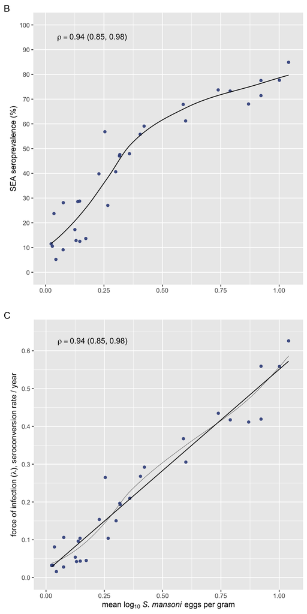

```r
d3c <- d3 %>%
  group_by(vid, arm) %>%
  mutate(nsea = ifelse(is.na(sea_pos),0,1),
         nkk = ifelse(is.na(kk_pos),0,1)
         ) %>%
  summarize(nsea = sum(nsea),
            meansea = mean(logsea),
            prevsea = mean(sea_pos),
            nkk = sum(nkk),
            meankk = mean(logepg,na.rm=T),
            prevkk = mean(kk_pos,na.rm=T)
            )



# merge in FOI estimates
d3c <- d3c %>%
  left_join(foi_ests,by=c("vid")) %>%
  ungroup()

# estimate spearman correlation
dcorrkk <- d3c %>%
  ungroup() %>%
  mutate(corspkk=cor(prevsea,prevkk,method="spearman"),
         cormukk=cor(meansea,prevkk,method="spearman"),
         corpseakkmu=cor(prevsea,meankk,method="spearman"),
         cormukkfoi=cor(lambda,meankk,method="spearman"),
         corpkkfoi=cor(lambda,prevkk,method="spearman")) %>%
  slice(1)

# bootstrap resample to estimate 95% confidence intervals
set.seed(23532)
dcorrkk_boot <- foreach(booti = 1:1000, .combine = rbind) %do% {
  pd <- sample_frac(d3c,size=1, replace = TRUE) %>%
    mutate(corspkk=cor(prevsea,prevkk,method="spearman"),
           cormukk=cor(meansea,prevkk,method="spearman"),
           corpseakkmu=cor(prevsea,meankk,method="spearman"),
           cormukkfoi=cor(lambda,meankk,method="spearman"),
           corpkkfoi=cor(lambda,prevkk,method="spearman")) %>%
    slice(1) %>%
    dplyr::select(corspkk,cormukk,corpseakkmu,cormukkfoi,corpkkfoi)
}

corpseakkmu_ci <- quantile(dcorrkk_boot$corpseakkmu,prob = c(0.025,0.975))
corpseakkmu_print <- paste0(sprintf("%1.2f",dcorrkk$corpseakkmu)," (", sprintf("%1.2f",corpseakkmu_ci[1]),", ",sprintf("%1.2f",corpseakkmu_ci[2]),")")

cormukkfoi_ci <- quantile(dcorrkk_boot$cormukkfoi,prob = c(0.025,0.975))
cormukkfoi_print <- paste0(sprintf("%1.2f",dcorrkk$cormukkfoi)," (", sprintf("%1.2f",cormukkfoi_ci[1]),", ",sprintf("%1.2f",cormukkfoi_ci[2]),")")


sp_epg_plot <- ggplot(data=d3c,aes(x=meankk,y=prevsea)) +
  geom_point(color=vircols[3],alpha=0.9) +
  geom_smooth(method="loess",se=FALSE,color="black",lwd=0.5) +
  annotate("text",x=0.05,y=0.95,label=paste("rho ==",deparse(corpseakkmu_print)),parse=TRUE, hjust=0)+
  scale_y_continuous(breaks=seq(0,1,by=0.1),labels=sprintf("%1.0f",seq(0,1,by=0.1)*100))+
  coord_cartesian(ylim=c(0,1),xlim=c(0,1.05))+
  labs(x="",y="SEA seroprevalence (%)",tag = "B") +
  theme(panel.grid.minor.y=element_blank())

foi_epg_plot <- ggplot(data=d3c,aes(x=meankk,y=lambda)) +
  geom_point(color=vircols[3],alpha=0.9) +
  geom_smooth(method="loess",se=FALSE,color="gray40",lwd=0.25) +
  geom_smooth(method="glm",se=FALSE,color="black",lwd=0.5) +
  annotate("text",x=0.05,y=0.625,label=paste("rho ==", deparse(cormukkfoi_print)),parse=TRUE, hjust=0)+
  scale_y_continuous(breaks=seq(0,0.6,by=0.1))+
  coord_cartesian(ylim=c(0,0.65),xlim = c(0,1.05))+
  labs(x=expression(paste("mean ",log[10],italic(" S. mansoni"), " eggs per gram")),y=expression(paste("force of infection (",lambda,"), seroconversion rate / year")) ,eval=TRUE, tag = "C")


vil_trans_plots <- grid.arrange(sp_epg_plot,foi_epg_plot,nrow=2,ncol=1)
```

```r
ggsave(filename=here("output","mbita-village-transmission-ests.png"),plot=vil_trans_plots,device="png",width=4,height=8)
```

## Save FOI estimates for future use

Save village-level force of infection estimates for future use in downstream data visualizations.

```r
saveRDS(foi_ests,file=here("output","mbita-village-foi.rds"))
```

# Figure S4

Correlation between years for village-level SEA seroprevalence and Kato-Katz prevalence

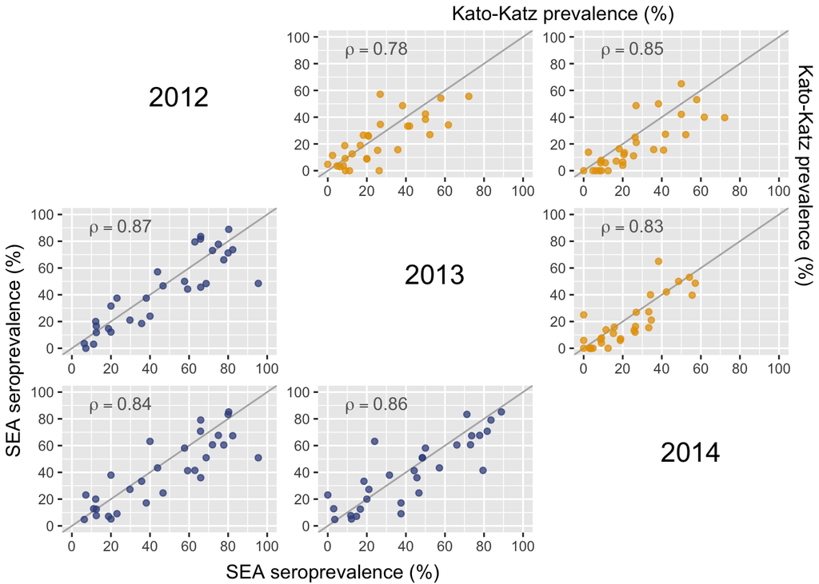

```r
#--------------------------------
# custom pairs plot
# ggpairs() just too hard to
# work with for this one
#--------------------------------
#--------------------------------
# spread the SEA and KK data
#--------------------------------
dvil_sea <- dvil %>%
  dplyr::select(vid,yearf,sea_prev) %>%
  spread(yearf,-vid) %>%
  rename(sea2012="2012",sea2013="2013",sea2014="2014")

dvil_kk <- dvil %>%
  dplyr::select(vid,yearf,kk_prev) %>%
  spread(yearf,-vid) %>%
  rename(kk2012="2012",kk2013="2013",kk2014="2014")

#--------------------------------
# x, y scatter plot function
# with correlation estimate
#--------------------------------
xypairs <- function(data,mapping,point_color) {
  # estimate correlation
  xycor <- cor(x=data[,gsub("~","",paste(mapping[1]))],
               y=data[,gsub("~","",paste(mapping[2]))],
               method="spearman")
  # plot the data
  ggplot(data = data, mapping = mapping)+
    geom_abline(intercept=0,slope=1,col="gray70")+
    geom_point(color=point_color,alpha=0.75)+
    annotate("text",x=0.25,y=0.9,label=paste("rho ==",sprintf("%1.2f",xycor)),parse=TRUE,color="gray40")+
    scale_y_continuous(breaks=seq(0,1,by=0.2),labels=sprintf("%1.0f",seq(0,1,by=0.2)*100))+
    scale_x_continuous(breaks=seq(0,1,by=0.2),labels=sprintf("%1.0f",seq(0,1,by=0.2)*100))+
    coord_cartesian(xlim=c(0,1),ylim=c(0,1)) +
    labs(x=NULL,y=NULL) +
    theme(
      plot.margin = unit(c(1,1,1,1),"mm")
    )
    # theme_minimal()
}

#--------------------------------
# make the panels
#--------------------------------
p1213 <- xypairs(data=dvil_sea,aes(x=sea2012,y=sea2013),point_color=vircols[3])
p1214 <- xypairs(data=dvil_sea,aes(x=sea2012,y=sea2014),point_color=vircols[3])
p1314 <- xypairs(data=dvil_sea,aes(x=sea2013,y=sea2014),point_color=vircols[3])
l2012 <- textGrob(label = "2012",x=unit(0.6,"npc"),y=unit(0.6,"npc"),gp=gpar(cex=1.4))
l2013 <- textGrob(label = "2013",x=unit(0.6,"npc"),y=unit(0.6,"npc"),gp=gpar(cex=1.4))
l2014 <- textGrob(label = "2014",x=unit(0.6,"npc"),y=unit(0.6,"npc"),gp=gpar(cex=1.4))
kk1213 <- xypairs(data=dvil_kk,aes(x=kk2012,y=kk2013),point_color=cbPalette[2])
kk1214 <- xypairs(data=dvil_kk,aes(x=kk2012,y=kk2014),point_color=cbPalette[2])
kk1314 <- xypairs(data=dvil_kk,aes(x=kk2013,y=kk2014),point_color=cbPalette[2])

#--------------------------------
# arrange the pairs plot
#--------------------------------
pairs_sea_kk <- grid.arrange(grobs = list(l2012,kk1213,kk1214,
                                       p1213,l2013,kk1314,
                                       p1214,p1314,l2014),
                       widths = c(1,1,1),
                       heights = c(1,1,1),
                       layout_matrix = matrix(1:9,ncol=3,nrow=3,byrow=TRUE),
                       left = textGrob(label="SEA seroprevalence (%)",y=0.4,x=0.5,rot=90),
                       bottom = textGrob(label="SEA seroprevalence (%)",y=0.5,x=0.4),
                       right = textGrob(label="Kato-Katz prevalence (%)",y=0.7,x=0.5,rot=270),
                       top = textGrob(label="Kato-Katz prevalence (%)",y=0.5,x=0.7)
                       )
```

```r
ggsave(filename = here("output","mbita-sea-kk-year-prev-pairs.png"),plot = pairs_sea_kk, device = "png",width=6,height=6)
```

## Simplified version with only SEA

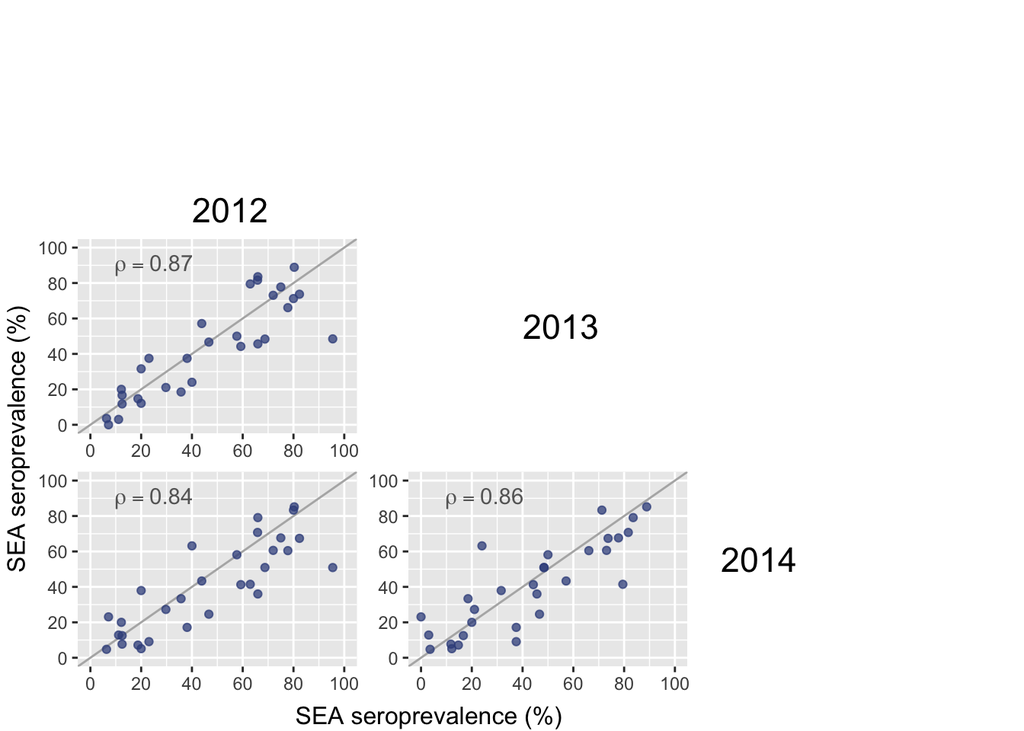

```r
#--------------------------------
# make the panels
#--------------------------------
p1213 <- xypairs(data=dvil_sea,aes(x=sea2012,y=sea2013),point_color=vircols[3])
p1214 <- xypairs(data=dvil_sea,aes(x=sea2012,y=sea2014),point_color=vircols[3])
p1314 <- xypairs(data=dvil_sea,aes(x=sea2013,y=sea2014),point_color=vircols[3])
l2012 <- textGrob(label = "2012",x=unit(0.6,"npc"),y=unit(0.1,"npc"),gp=gpar(cex=1.4))
l2013 <- textGrob(label = "2013",x=unit(0.6,"npc"),y=unit(0.6,"npc"),gp=gpar(cex=1.4))
l2014 <- textGrob(label = "2014",x=unit(0.2,"npc"),y=unit(0.6,"npc"),gp=gpar(cex=1.4))

#--------------------------------
# arrange the pairs plot
#--------------------------------
pairs_sea <- grid.arrange(grobs = list(l2012,
                                       p1213,l2013,
                                       p1214,p1314,l2014),
                       widths = c(1,1,1),
                       heights = c(1,1,1),
                       layout_matrix = matrix(c(1,NA,NA,2,3,NA,4,5,6),nrow=3,ncol=3,byrow=T),
                       left = textGrob(label="SEA seroprevalence (%)",y=0.4,x=0.5,rot=90),
                       bottom = textGrob(label="SEA seroprevalence (%)",y=0.5,x=0.4),
                       # right = textGrob(label="Kato-Katz prevalence (%)",y=0.7,x=0.5,rot=270),
                       # top = textGrob(label="Kato-Katz prevalence (%)",y=0.5,x=0.7)
                       )
```

```r
ggsave(filename = here("output","mbita-sea-year-prev-pairs.png"),plot = pairs_sea, device = "png",width=6,height=6)
```

# Figure 3

## Relationship between FOI and seroprevalence with smaller samples

There is a strong relationship between village-level seroprevalence and force of infection in the analyses above. To estimate force of infection, many observations are required, whereas estimating seroprevalence requires far fewer.

Examine the influence of reducing the number of samples per village used to estimate mean SEA MFI and seroprevalence, and mean Kato-Katz EPG and prevalence. Determine whether estimates are still correlated with village-level force of infection estimated in the full sample.

## Downsample seroprevalence estimates

Consider the effect of smaller samples by resampling with replacement between 20 and 200 children per village from the empirical data. Within each sample, estimate mean log10 MFI for SEA, SEA seroprevalence, and Kato-Katz eggs per gram (EPG) and prevalence.

The procedure is repeated over 1000 replicates.

```r
# estimate means with sample sizes of betweeen 20 and 200 observations
ssests <- foreach(ssi=seq(200,20,by=-20),.combine=rbind) %:%
  foreach(iteri=1:1000,.combine=rbind) %dopar% {
    set.seed(iteri)
    di <- d3 %>%
    group_by(vid) %>%
    sample_n(size = ssi,replace = TRUE) %>%
    summarize(meanmfi = mean(logsea,na.rm=TRUE),
              seroprev = mean(sea_pos,na.rm=TRUE),
              kkprev = mean(kk_pos,na.rm=TRUE),
              kkmean = mean(logepg,na.rm=TRUE)
              ) %>%
    mutate(ss=ssi,iter=iteri)
}

# merge in the means with the full sample
d4c <- d3c %>%
  dplyr::select(vid,true_mu=meansea,true_seroprev=prevsea,true_kkprev=prevkk,true_kkmean=meankk, lambda)

ssests2 <- left_join(ssests,d4c,by=c("vid"))
```

Across the 1000 downsample simulations, estimate the standard deviation of estimates, bootstrap 95% CIs, bias and mean squared error (MSE).

```r
# average over simulation replicates
# calculate mean, standard deviation, percentile 95% CIs, bias and MSE
ssmeans <- ssests2 %>%
  group_by(vid,ss) %>%
  summarize(

            # MFI
            true_mu = mean(true_mu),
            mu=mean(meanmfi),
            mu_sd=sd(meanmfi),
            mu_lb=quantile(meanmfi,probs=c(0.025)),
            mu_ub=quantile(meanmfi,probs=c(0.975)),
            mu_mse=mean((meanmfi-true_mu)^2),
            mu_bias=mean(meanmfi-true_mu),

            # SEA seroprevalence
            true_seroprev=mean(true_seroprev),
            prevsea = mean(seroprev),
            prevsea_sd = sd(seroprev),
            prevsea_lb = quantile(seroprev,probs=c(0.025)),
            prevsea_ub = quantile(seroprev,probs=c(0.975)),
            prevsea_mse = mean((seroprev-true_seroprev)^2),
            prevsea_bias = mean(seroprev-true_seroprev),

            # KK EPG
            true_kkmu=mean(true_kkmean),
            meankk = mean(kkmean),
            meankk_sd = sd(kkmean),
            meankk_lb=quantile(kkmean,probs=c(0.025)),
            meankk_ub=quantile(kkmean,probs=c(0.975)),
            meankk_mse=mean((kkmean-true_kkmean)^2),
            meankk_bias=mean(kkprev-true_kkmean),

            # KK prevalence
            true_kkprev=mean(true_kkprev),
            prevkk = mean(kkprev),
            prevkk_sd = sd(kkprev),
            prevkk_lb=quantile(kkprev,probs=c(0.025)),
            prevkk_ub=quantile(kkprev,probs=c(0.975)),
            prevkk_mse=mean((kkprev-true_kkprev)^2),
            prevkk_bias=mean(kkprev-true_kkprev)
            )
```

Also estimate the correlation between community level FOI measured by SEA and the other community level measures.

```r
#-------------------------------
# correlation betwen community-level means and FOI,
# over bootstrap estimates
#-------------------------------
sscorr_foi1 <- ssests2 %>%
  group_by(ss,iter) %>%
  filter(!is.na(lambda)) %>%
  summarize(cor_mean=cor(meanmfi,lambda,method="spearman"),
            cor_seroprev=cor(seroprev,lambda,method="spearman"),
            cor_kkmean=cor(kkmean,lambda,method="spearman"),
            cor_kkprev=cor(kkprev,lambda,method="spearman"))

sscorr_foi2 <- sscorr_foi1 %>%
  ungroup() %>%
  group_by(ss) %>%
  summarize(cor_musea=mean(cor_mean),
            cor_musea_lb=quantile(cor_mean,probs=c(0.025)),
            cor_musea_ub=quantile(cor_mean,probs=c(0.975)),

            cor_prevsea = mean(cor_seroprev),
            cor_prevsea_lb = quantile(cor_seroprev,probs=c(0.025)),
            cor_prevsea_ub = quantile(cor_seroprev,probs=c(0.975)),

            cor_meankk = mean(cor_kkmean),
            cor_meankk_lb = quantile(cor_kkmean,probs=c(0.025)),
            cor_meankk_ub = quantile(cor_kkmean,probs=c(0.975)),

            cor_prevkk = mean(cor_kkprev),
            cor_prevkk_lb = quantile(cor_kkprev,probs=c(0.025)),
            cor_prevkk_ub = quantile(cor_kkprev,probs=c(0.975))
            )

#-------------------------------
# reshape long just to make
# it easier to plot in ggplot
#-------------------------------

sscorr_foi_seamfi <- sscorr_foi2 %>%
  dplyr::select(ss,cor = cor_musea, cor_lb = cor_musea_lb, cor_ub = cor_musea_ub) %>%
  mutate(measure="SEA MFI-bg")

sscorr_foi_seaprev <- sscorr_foi2 %>%
  dplyr::select(ss,cor = cor_prevsea, cor_lb = cor_prevsea_lb, cor_ub = cor_prevsea_ub) %>%
  mutate(measure="SEA seroprevalence")

sscorr_foi_kkmean <- sscorr_foi2 %>%
  dplyr::select(ss,cor = cor_meankk, cor_lb = cor_meankk_lb, cor_ub = cor_meankk_ub) %>%
  mutate(measure="Kato-Katz EPG")

sscorr_foi_kkprev <- sscorr_foi2 %>%
  dplyr::select(ss,cor = cor_prevkk, cor_lb = cor_prevkk_lb, cor_ub = cor_prevkk_ub) %>%
  mutate(measure="Kato-Katz prevalence")

sscorr_foi_long <- bind_rows(sscorr_foi_seamfi,sscorr_foi_seaprev,sscorr_foi_kkmean,sscorr_foi_kkprev) %>%
  mutate(measure=factor(measure,levels=c("SEA MFI-bg","SEA seroprevalence","Kato-Katz EPG","Kato-Katz prevalence")))

sscorr_foi_long_reps <- sscorr_foi1 %>%
  pivot_longer(cols = starts_with("cor_"), names_to = "outcome", names_prefix = "cor_",values_to = "cor") %>%
  mutate(measure = case_when (
    outcome == "kkmean" ~ "Kato-Katz EPG",
    outcome == "kkprev" ~ "Kato-Katz prevalence",
    outcome == "mean"   ~ "SEA MFI-bg",
    outcome == "seroprev" ~ "SEA seroprevalence"
  ),
  measure = factor(measure, levels = c("SEA MFI-bg","SEA seroprevalence","Kato-Katz EPG","Kato-Katz prevalence"))
         )
```

Plot a figure of the correlation between the seroconversion rate estimated in the full sample versus cluster level SEA mean MFI-bg or seroprevalence (blue) or cluster level mean EPG or prevalence by Kato-Katz (orange) estimated at each smaller sample size

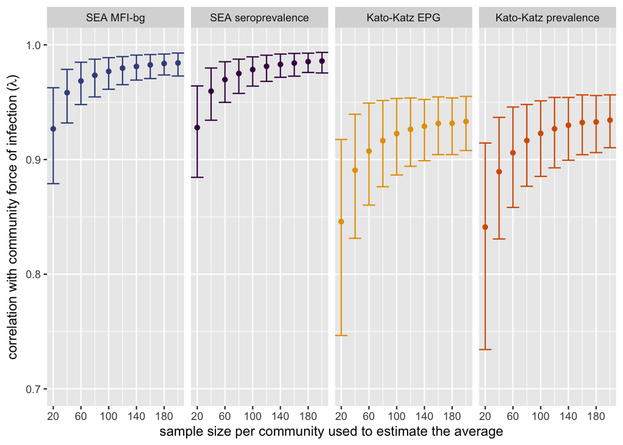

```r
pcols <- c(vircols[c(3,1)],cbPalette[c(2,7)])
sscorfoip <- ggplot(data=sscorr_foi_long,aes(x=ss,y=cor, color = measure)) +
  # geom_ribbon(aes(ymin=cor_mu_lb,ymax=cor_mu_ub),color=NA,fill=cblue,alpha=0.2)+
  # geom_line(aes(y=cor_mu),color=cblue) +
  # geom_ribbon(aes(ymin=cor_pr_lb,ymax=cor_pr_ub),color=NA,alpha=0.2)+
  # geom_line(aes(y=cor_pr))+
  facet_grid(~measure)+
  # geom_jitter(data=sscorr_foi_long_reps %>% filter(iter<=500), aes(x = ss, y= cor), col = cbPalette[7],alpha=0.2,size =0.1,width=5)+
  geom_errorbar(aes(ymin=cor_lb,ymax=cor_ub))+
  geom_point(pch=19)+
  scale_fill_manual(values=pcols)+
  scale_color_manual(values=pcols)+
  scale_y_continuous(breaks=seq(0,1,by=0.1))+
  scale_x_continuous(breaks=seq(20,200,by=40))+
  coord_cartesian(ylim=c(0.7,1),xlim=c(20,200))+
  labs(y=expression(paste("correlation with community force of infection (",lambda,")")),x="sample size per community used to estimate the average") +
  theme(legend.position="none")
sscorfoip
```

```r
ggsave(filename=here("output","mbita-village-foi-correlation-ss-sim.png"),plot=sscorfoip,device="png",width=8,height=4)
```